# ExAC Conservation Analysis

## ExAC Annotation

```r
# write file of regions of SNPs for input to tabix
write.table(data %>%
                mutate(chr = gsub('chr', '', chr),
                       # ExAC built on hg19, supply region to tabix works properly
                       snp_region = paste0(chr, ':', snp_position, '-', snp_position + 1)) %>%
                select(snp_region) ,
            file = '../produced_data/tabix_input_snp_regions.txt',
            quote = F, row.names = F, col.names = F, sep = '\t')
```

We can extract the ExAC annotation from the large VCF file using tabix. The necessary `.tbi` file, `ExAC.r0.3.1.sites.vep.vcf.gz.tbi` must be created first (`tabix ../ref/ExAC.r0.3.1.sites.vep.vcf.gz`). In the below command, the file is read in and `tabix` is executed for each region, one per line, in the input text file and the result appended to the file. The below command takes awhile to run, so it is not evaluated automatically in the script.

```r
while read line; do
    tabix ../ref/ExAC.r0.3.1.sites.vep.vcf.gz $line >> ../ref/snp_exac_annot.txt
done < ../produced_data/tabix_input_snp_regions.txt
```

Now, let’s read in the ExAC annotation for our SNPs.

```r
# this will be ~2x as big as the number of SNPs because 2bp were extracted for each SNP
exac_annot <- read.table('../ref/snp_exac_annot.txt', sep = '\t', header = F)
colnames(exac_annot) <- c('chr', 'position', 'snp_id', 'ref_allele', 'alt_allele', 'quality', 'filter', 'info')
# get info column names
# split by ';', separates info columns
example_info <- unlist(strsplit(exac_annot$info[1], split = ';'))
# get names only, e.g. key=value
info_names <- unlist(lapply(strsplit(example_info, split = '='), `[[`, 1))
exac_annot <- separate(exac_annot, info, into = info_names, sep = ';') %>%
    # from info fields, only save CSQ, only one we care about right now
    select(chr:filter, CSQ)
# parse CSQ column, consequence annotations from Ensembl VEP (Variant Effect Predictor). Description of fields taken from header of vcf file
csq_fields <- 'Allele|Consequence|IMPACT|SYMBOL|Gene|Feature_type|Feature|BIOTYPE|EXON|INTRON|HGVSc|HGVSp|cDNA_position|CDS_position|Protein_position|Amino_acids|Codons|Existing_variation|ALLELE_NUM|DISTANCE|STRAND|VARIANT_CLASS|MINIMISED|SYMBOL_SOURCE|HGNC_ID|CANONICAL|TSL|CCDS|ENSP|SWISSPROT|TREMBL|UNIPARC|SIFT|PolyPhen|DOMAINS|HGVS_OFFSET|GMAF|AFR_MAF|AMR_MAF|ASN_MAF|EAS_MAF|EUR_MAF|SAS_MAF|AA_MAF|EA_MAF|CLIN_SIG|SOMATIC|PHENO|PUBMED|MOTIF_NAME|MOTIF_POS|HIGH_INF_POS|MOTIF_SCORE_CHANGE|LoF_info|LoF_flags|LoF_filter|LoF|context|ancestral'
csq_fields <- unlist(strsplit(csq_fields, split = '[|]'))
exac_annot <- separate(exac_annot, CSQ, into = csq_fields, sep = '[|]') %>%
    mutate(Allele = gsub('CSQ=', '', Allele))
exac_annot <- exac_annot %>%
    mutate(annot = strsplit(Consequence, '&')) %>%
    unnest(annot) %>%
    select(chr:Allele, -Consequence, annot, IMPACT:ancestral) %>%
    distinct()
```

```r
data <- data %>%
        mutate(chr = as.numeric(gsub('chr', '', chr))) %>%
        left_join(select(exac_annot, chr, position, snp_id, annot),
                 by = c('chr', 'snp_position' = 'position'))
```

```
NAs introduced by coercion
```

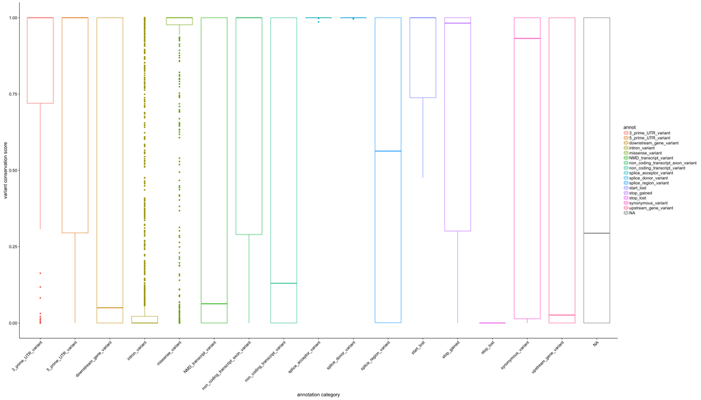

```r
ggplot(data, aes(annot, mean_cons_score)) +
    geom_boxplot(aes(color = annot)) +
    labs(y = 'variant conservation score',
         x = 'annotation category') +
    theme(axis.text.x = element_text(angle = 45, hjust = 1))
```

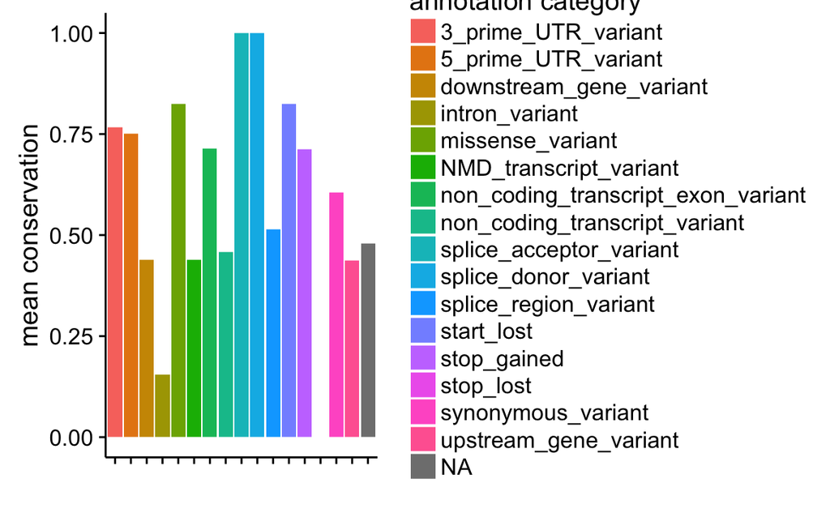

```r
ggplot(select(data, annot, annot_cons_mean) %>% distinct() %>% arrange(annot_cons_mean), aes(annot, annot_cons_mean)) +
    geom_bar(stat = 'identity', aes(fill = annot)) + scale_fill_discrete(name = 'annotation category') +
    labs(x = '', y = 'mean conservation') +
    theme(axis.text.x = element_blank())
```

We can see that splice acceptor/donor variants are the most highly conserved categories, along with missense variants, which is what we’d expect. Intron variants are the one of the least conserved categories, which is also what we would expect.

## High Confidence Calls

Let’s look at the list of high confidence calls and see where they fall in the conservation distribution.

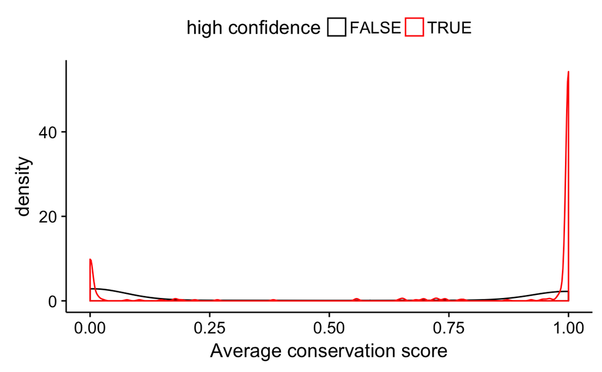

```r
ggplot(filter(data, category != 'control'), aes(mean_cons_score)) +
    geom_density(aes(color = high_confidence)) + theme(legend.position = 'top') +
    scale_color_manual(values = c('black', 'red')) +
    labs(x = 'Average conservation score',
         color = 'high confidence')
```

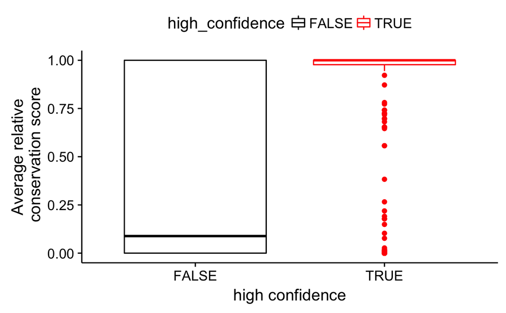

```r
ggplot(data, aes(x = high_confidence, y = mean_cons_score)) +
    geom_boxplot(aes(color = high_confidence)) +
    labs(x = 'high confidence', y = 'Average relative\n conservation score') +
    scale_color_manual(values = c('black', 'red')) +
    theme(legend.position = 'top')
```

```r
t.test(filter(data, high_confidence == TRUE)$mean_cons_score,
       filter(data, high_confidence == FALSE)$mean_cons_score)
```

```
    Welch Two Sample t-test

data:  filter(data, high_confidence == TRUE)$mean_cons_score and filter(data, high_confidence == FALSE)$mean_cons_score
t = 16.672, df = 345.29, p-value < 2.2e-16
alternative hypothesis: true difference in means is not equal to 0
95 percent confidence interval:
 0.3195783 0.4050683
sample estimates:
mean of x mean of y
0.8082258 0.4459025
```

We can see that the conservation distribution for high confidence calls is skewed towards highly conserved positions. The boxplot further highlights the difference in conservation distribution for high confidence calls. The 95% confidence interval for the true difference in means does not include 0 and the p-value is much smaller than 0.05, indicating that the high confidence calls are on average more conserved than non-high confidence calls.

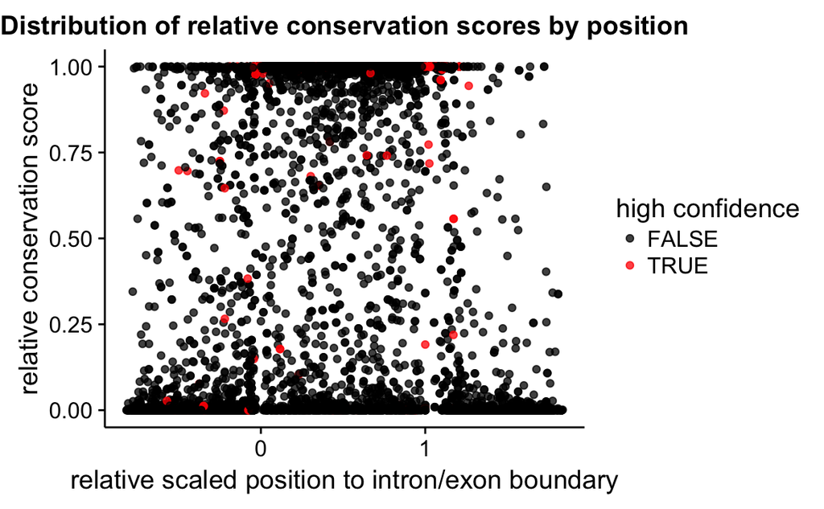

```r
ggplot(data, aes(rel_position_scaled, mean_cons_score)) +
    geom_point(alpha = 0.75, aes(color = high_confidence)) +
    scale_color_manual(values = c('black', 'red'), name = 'high confidence') +
    labs(x = 'relative scaled position to intron/exon boundary',
         y = 'relative conservation score',
         title = 'Distribution of relative conservation scores by position')
```

## Top Variants

```r
# read in mapping between ensembl exon IDs and gene IDs, 2011 release 63, hg19
mapping <- read.table(file = '../produced_data/ensembl_exon_gene_id_mapping.txt',
                      col.names = c('ensembl_gene_id', 'ensembl_transcript_id', 'ensembl_exon_id'))
data <- data %>%
    left_join(select(mapping, ensembl_gene_id, ensembl_id = ensembl_exon_id), by = 'ensembl_id')
# grab the closest release from biomaRt, release 67, and corresponding RefSeq IDs
mart <- biomaRt::useMart('ENSEMBL_MART_ENSEMBL', dataset = 'hsapiens_gene_ensembl',
                host = "may2012.archive.ensembl.org")
GO_terms <- biomaRt::getBM(mart = mart,
                         attributes = c('ensembl_gene_id', 'external_gene_id', 'go_id',
                                        'name_1006', 'definition_1006'),
                         filters = c('ensembl_gene_id'),
                         values = data$ensembl_gene_id)
top <- data %>%
    filter(high_confidence == TRUE) %>%
    arrange(desc(mean_cons_score)) %>%
    slice(1:20) %>%
    left_join(select(GO_terms, ensembl_gene_id, external_gene_id) %>% distinct(), by = 'ensembl_gene_id')
top %>%
    select(mean_cons_score, annot, external_gene_id)
```

| mean_cons_score | annot | external_gene_id |
| --- | --- | --- |
| 1 | NA | RAB40C |
| 1 | NA | RAB40C |
| 1 | NA | RAB40C |
| 1 | NA | RAB40C |
| 1 | splice_acceptor_variant | NA |
| 1 | non_coding_transcript_variant | NA |
| 1 | splice_region_variant | NA |
| 1 | non_coding_transcript_exon_variant | NA |
| 1 | non_coding_transcript_variant | NA |
| 1 | intron_variant | RBL2 |

[output cut: 10 more lines]

- RAB40C - member RAS oncogene family
- RBL2 - RB transcriptional corepressor like 2. Diseases associated include retinoblastoma and retinal cancer. Among related pathways are cell cycle and adipogenesis
- SLC28A2 - solute carrier family 28 member 2, nucleoside binding, purine nucleoside transmembrane transporter activity.
- USH1C - scaffold protein that functions in the assembly of Usher protein complexes. Defects in this gene are the cause of Usher syndrome type 1C and non-syndromic sensorineural deafness recessive type 18
- MLF2 - myeloid leukemia factor 2, diseases associated include myeloid leukemia and leukemia.

Now, let’s filter by relative conservation (conservation / annotation category mean) and see what the top genes are.

```r
top_relative <- data %>%
    filter(high_confidence == TRUE) %>%
    arrange(desc(rel_mean_cons_score)) %>%
    slice(1:20) %>%
    left_join(select(GO_terms, ensembl_gene_id, external_gene_id) %>% distinct(), by = 'ensembl_gene_id')
top_relative %>%
    select(rel_mean_cons_score, annot, external_gene_id)
```

| rel_mean_cons_score | annot | external_gene_id |
| --- | --- | --- |
| 6.475367 | intron_variant | RBL2 |
| 6.475367 | intron_variant | RBL2 |
| 6.475367 | intron_variant | CA6 |
| 6.475367 | intron_variant | CA6 |
| 6.475367 | intron_variant | CA6 |
| 6.475367 | intron_variant | CA6 |
| 6.475367 | intron_variant | TRPM1 |
| 6.475367 | intron_variant | TRPM1 |
| 6.475367 | intron_variant | TRPM1 |
| 6.475367 | intron_variant | TRPM1 |

[output cut: 10 more lines]

May not be best to rank by relative conservation, the top 20 variants are all intron variants, most likely because the average conservation for intron variants is low, resulting in the relative conservation to be higher.

RBL2 is second when variants are sorted by mean conservation score and first when sorted by relative conservation score.

- CA6 - one of several isozymes of carbonic anhydrase. Found only in salivary glands and saliva
- TRPM1 - encodes member of transient receptor potential melastatin subfamily of transient receptor potential ion channels. Protein is a calium permeable cation channel that is expressed in melanocytes and may play a role in melanin synthesis. Specific mutations in this gene cause autosomal recessive complete congenital stationary night blindness-1C. Expression of this protein is inversely correlated with melanoma agressiveness and isu sed as a prognostic marker for melanoma metastasis.
- KRT84 - member of keratin gene family
- TK2 - thymidine kinase 2, mitochondrial. Encodes a deoxyribonucleoside kinase that specifically phosphorylates thymidine, deoxycytidine, and deoxyuridine. Localizes to mitochondria, required for mitochondrial DNA synthesis. Mutations in this gene are associated with a myopathic form of mitochondrial DNA depletion syndrome. Alternate splcing results in multiple transcript variants encoding distinct isoforms, some of which lack transit peptide, so are not localized to mitochondria.